# Global Forecasting Models: Forecasting thousand time series

**Joaquín Amat Rodrigo, Javier Escobar Ortiz**

*July, 2024*

**More about forecasting**

- [ARIMA and SARIMAX models with python](https://cienciadedatos.net/documentos/py51-arima-sarimax-models-python.html)
- [Time series forecasting with machine learning](https://cienciadedatos.net/documentos/py27-time-series-forecasting-python-scikitlearn.html)
- [Forecasting time series with gradient boosting: XGBoost, LightGBM and CatBoost](https://www.cienciadedatos.net/documentos/py39-forecasting-time-series-with-skforecast-xgboost-lightgbm-catboost.html)
- [Forecasting time series with XGBoost](https://cienciadedatos.net/documentos/py56-forecasting-time-series-with-xgboost.html)
- [Global Forecasting Models: Multi-series forecasting](https://www.cienciadedatos.net/documentos/py44-multi-series-forecasting-skforecast.html)
- [Global Forecasting Models: Comparative Analysis of Single and Multi-Series Forecasting Modeling](https://cienciadedatos.net/documentos/py53-global-forecasting-models.html)
- [Probabilistic forecasting](https://www.cienciadedatos.net/documentos/py42-probabilistic-forecasting.html)
- [Forecasting with deep learning](https://www.cienciadedatos.net/documentos/py54-forecasting-with-deep-learning.html)
- [Forecasting energy demand with machine learning](https://www.cienciadedatos.net/documentos/py29-forecasting-electricity-power-demand-python.html)
- [Forecasting web traffic with machine learning](https://www.cienciadedatos.net/documentos/py37-forecasting-web-traffic-machine-learning.html)
- [Intermittent demand forecasting](https://www.cienciadedatos.net/documentos/py48-intermittent-demand-forecasting)
- [Modelling time series trend with tree-based models](https://www.cienciadedatos.net/documentos/py49-modelling-time-series-trend-with-tree-based-models.html)
- [Bitcoin price prediction with Python](https://www.cienciadedatos.net/documentos/py41-forecasting-cryptocurrency-bitcoin-machine-learning-python.html)
- [Stacking ensemble of machine learning models to improve forecasting](https://cienciadedatos.net/documentos/py52-stacking-ensemble-models-forecasting.html)
- [Interpretable forecasting models](https://cienciadedatos.net/documentos/py57-interpretable-forecasting-models.html)

[figure not shown]

## Introduction

When faced with scenarios involving the prediction of hundreds or thousands of time series, a crucial decision arises: should one develop individual models for each series, or should one use a unified model to handle them all at once?

In **Single-Series Modeling (Local Forecasting Model)**, a separate predictive model is created for each time series. While this method provides a comprehensive understanding of each series, its scalability can be challenged by the need to create and maintain hundreds or thousands of models.

**Multi-Series Modeling (Global Forecasting Model)** involves building a single predictive model that considers all time series simultaneously. It attempts to capture the core patterns that govern the series, thereby mitigating the potential noise that each series might introduce. This approach is computationally efficient, easy to maintain, and can yield more robust generalizations across time series, albeit potentially at the cost of sacrificing some individual insights.

This document shows how to forecast more than 1000 series with a single model including exogenous features with some of them having different values per series.

## Libraries

Libraries used in this document.

```python
# Data management
# ==============================================================================
import numpy as np

# Plots
# ==============================================================================
import matplotlib.pyplot as plt
import matplotlib.ticker as ticker
plt.style.use('seaborn-v0_8-darkgrid')

# Forecasting
# ==============================================================================
import skforecast
import lightgbm
from lightgbm import LGBMRegressor
from sklearn.preprocessing import OrdinalEncoder
from sklearn.compose import make_column_transformer
from skforecast.ForecasterAutoregMultiSeries import ForecasterAutoregMultiSeries
from skforecast.model_selection_multiseries import backtesting_forecaster_multiseries
from skforecast.model_selection_multiseries import bayesian_search_forecaster_multiseries
from skforecast.preprocessing import series_long_to_dict
from skforecast.preprocessing import exog_long_to_dict
from skforecast.datasets import fetch_dataset

# Configuración
# ==============================================================================
import warnings
from skforecast.exceptions import MissingValuesWarning
warnings.filterwarnings('once')

print('Versión skforecast:', skforecast.__version__)
print('Versión lightgbm:', lightgbm.__version__)
```

```
Versión skforecast: 0.13.0
Versión lightgbm: 4.4.0
```

## Data

Data used in this document has been obtained from the The Building Data Genome Project 2 https://github.com/buds-lab/building-data-genome-project-2. The dataset contains information on the energy consumption of more than 1500 buildings. The time range of the times-series data is the two full years (2016 and 2017) and the frequency is hourly measurements of electricity, heating and cooling water, steam, and irrigation meters. Additionally, the dataset includes information of the characteristics of the buildings and the weather conditions. Data has been aggregated to a daily resolution and only the electricity among the different energy sources has been considered.

```python
# Load data
# ==============================================================================
data = fetch_dataset(name='bdg2_daily')
print("Data shape:", data.shape)
data.head(3)
```

```
bdg2_daily
----------
Daily energy consumption data from the The Building Data Genome Project 2 with
building metadata and weather data. https://github.com/buds-lab/building-data-
genome-project-2
Miller, C., Kathirgamanathan, A., Picchetti, B. et al. The Building Data Genome
Project 2, energy meter data from the ASHRAE Great Energy Predictor III
competition. Sci Data 7, 368 (2020). https://doi.org/10.1038/s41597-020-00712-x
Shape of the dataset: (1153518, 17)
Data shape: (1153518, 17)
```

| timestamp | building_id | meter_reading | site_id | primaryspaceusage | sub_primaryspaceusage | sqm | lat | lng | timezone | airTemperature | cloudCoverage | dewTemperature | precipDepth1HR | precipDepth6HR | seaLvlPressure | windDirection | windSpeed |
| --- | --- | --- | --- | --- | --- | --- | --- | --- | --- | --- | --- | --- | --- | --- | --- | --- | --- |
| 2016-01-01 | Bear_assembly_Angel | 12808.1620 | Bear | Entertainment/public assembly | Entertainment/public assembly | 22117.0 | 37.871903 | -122.260729 | US/Pacific | 6.1750 | 1.666667 | -5.229167 | 0.0 | 0.0 | 1020.891667 | 68.750000 | 3.070833 |
| 2016-01-02 | Bear_assembly_Angel | 9251.0003 | Bear | Entertainment/public assembly | Entertainment/public assembly | 22117.0 | 37.871903 | -122.260729 | US/Pacific | 8.0875 | NaN | -1.404167 | 0.0 | 0.0 | 1017.687500 | 76.666667 | 3.300000 |
| 2016-01-03 | Bear_assembly_Angel | 14071.6500 | Bear | Entertainment/public assembly | Entertainment/public assembly | 22117.0 | 37.871903 | -122.260729 | US/Pacific | 10.1125 | NaN | 1.708333 | -6.0 | -2.0 | 1011.491667 | 91.666667 | 3.120833 |

```python
# Overall range of available dates
# ==============================================================================
print(
    f"Rage of dates available : {data.index.min()} --- {data.index.max()}  "
    f"(n_days={(data.index.max() - data.index.min()).days})"
)
```

```
Rage of dates available : 2016-01-01 00:00:00 --- 2017-12-31 00:00:00  (n_days=730)
```

```python
# Number of available dates per building
# ==============================================================================
(
    data
    .dropna(subset="meter_reading")
    .groupby(
        "building_id"
    ).size()
    .value_counts()
    .to_frame("n_buildings")
    .rename_axis("n_dates")
)
```

| n_dates | n_buildings |
| --- | --- |
| 731 | 1578 |

```python
# Missing values per feature
# ==============================================================================
data.isna().mean()
```

```
building_id              0.000000
meter_reading            0.000000
site_id                  0.000000
primaryspaceusage        0.012041
sub_primaryspaceusage    0.012041
sqm                      0.000000
lat                      0.148289
lng                      0.148289
timezone                 0.000000
airTemperature           0.000156
cloudCoverage            0.070233
dewTemperature           0.000263
precipDepth1HR           0.000156
precipDepth6HR           0.000156
seaLvlPressure           0.095577
windDirection            0.000156
windSpeed                0.000156
dtype: float64
```

All time series have the same length, starting from January 1, 2016 and ending on December 31, 2017. Exogenous variables have few missing values. **Skforecast does not require that the time series have the same length, and missing values are allowed as long as the underlying regressor can handle them, which is the case for LightGBM, XGBoost, and HistGradientBoostingRegressor.**

One of the key attributes associated with each building is its designated use. This feature may play a crucial role in influencing the energy consumption pattern, as distinct uses can significantly impact both the quantity and timing of energy consumption.

```python
# Number of buildings
# ==============================================================================
print(f"Number of buildings: {data['building_id'].nunique()}")
print(f"Number of building types: {data['primaryspaceusage'].nunique()}")
print(f"Number of building subtypes: {data['sub_primaryspaceusage'].nunique()}")
```

```
Number of buildings: 1578
Number of building types: 16
Number of building subtypes: 104
```

```python
# Number of buildings per type
# ==============================================================================
data.drop_duplicates(subset=['building_id'])['primaryspaceusage'].value_counts()
```

```
primaryspaceusage
Education                        604
Office                           296
Entertainment/public assembly    203
Public services                  166
Lodging/residential              149
Healthcare                        27
Other                             26
Parking                           23
Warehouse/storage                 14
Manufacturing/industrial          11
Retail                            11
Services                           9
Technology/science                 7
Food sales and service             6
Utility                            4
Religious worship                  3
Name: count, dtype: int64
```

```python
# Number of buildings per subtype
# ==============================================================================
(
    data
    .drop_duplicates(subset=['building_id', 'sub_primaryspaceusage'])['sub_primaryspaceusage']
    .value_counts()
)
```

```
sub_primaryspaceusage
Office                                295
College Classroom                     131
College Laboratory                    116
K-12 School                           109
Dormitory                              91
                                     ...
Park, Community Centers                 1
Performing Arts, Community Centers      1
Planetarium                             1
Prison/Incarceration                    1
office                                  1
Name: count, Length: 104, dtype: int64
```

For certain type and subtype categories, there are a limited number of buildings in the dataset. Types with fewer than 100 buildings and subtypes with fewer than 50 buildings are grouped into the "Other" category.

```python
# Group unfrequent categories
# ==============================================================================
infrequent_types = (
    data
    .drop_duplicates(subset=['building_id'])['primaryspaceusage']
    .value_counts()
    .loc[lambda x: x < 100]
    .index
    .tolist()
)
infrequent_subtypes = (
    data
    .drop_duplicates(subset=['building_id'])['sub_primaryspaceusage']
    .value_counts()
    .loc[lambda x: x < 50]
    .index
    .tolist()
)
print(f"\nInfequent types:")
print(', '.join(infrequent_types))
print(f"\nInfequent subtypes:")
print(', '.join(infrequent_subtypes))

data['primaryspaceusage'] = np.where(
    data['primaryspaceusage'].isin(infrequent_types),
    'Other',
    data['primaryspaceusage']
)
data['sub_primaryspaceusage'] = np.where(
    data['sub_primaryspaceusage'].isin(infrequent_subtypes),
    'Other',
    data['sub_primaryspaceusage']
)

display(data.drop_duplicates(subset=['building_id'])['primaryspaceusage'].value_counts())
display(data.drop_duplicates(subset=['building_id', 'sub_primaryspaceusage'])['sub_primaryspaceusage'].value_counts())
```

```
Infequent types:
Healthcare, Other, Parking, Warehouse/storage, Manufacturing/industrial, Retail, Services, Technology/science, Food sales and service, Utility, Religious worship

Infequent subtypes:
Other - Recreation, Fire Station, Research, Classroom, Residence Hall, Community Center, Other, Academic, Other - Public Services, Police Station, Gymnasium, Sports Stadium, Museum, Park, Fitness Center, Student Union, Community Center, Community Centers, Fire Station, Fire Stations, Athletic, Parki…
```

```
primaryspaceusage
Education                        604
Office                           296
Entertainment/public assembly    203
Public services                  166
Lodging/residential              149
Other                            141
Name: count, dtype: int64
```

```
sub_primaryspaceusage
Other                          612
Office                         295
College Classroom              131
College Laboratory             116
K-12 School                    109
Dormitory                       91
Primary/Secondary Classroom     84
Education                       67
Library                         54
Name: count, dtype: int64
```

## Exogenous variables

### Calendar features

```python
# Calendar features
# ==============================================================================
data['day_of_week'] = data.index.dayofweek
data['week_of_year'] = data.index.isocalendar().week.astype(int)
data['month'] = data.index.month
```

```python
# Cyclical encoding of calendar features
# ==============================================================================
data['sin_day_of_week'] = np.sin(2*np.pi*data['day_of_week']/7)
data['cos_day_of_week'] = np.cos(2*np.pi*data['day_of_week']/7)
data['sin_week_of_year'] = np.sin(2*np.pi*data['week_of_year']/52)
data['cos_week_of_year'] = np.cos(2*np.pi*data['week_of_year']/52)
data['sin_month'] = np.sin(2*np.pi*data['month']/12)
data['cos_month'] = np.cos(2*np.pi*data['month']/12)
```

**✎ Note**

For more information about calendar features and cyclical encoding visit [Calendar features](https://skforecast.org/latest/user_guides/calendar-features.html) and [Cyclical features in time series forecasting](https://skforecast.org/latest/faq/cyclical-features-time-series.html).

### Meteorological features

Meteorological variables are recorded at the site level, which means that for the same time stamp, the weather data is different depending on the location of the building. In other words, the exogenous variables are the same for all series, but with different values. **Skforecast allows you to include different exogenous variables and/or different values for each series in the dataset** (more details in the next section).

```python
# Number of different sites
# ==============================================================================
data['site_id'].nunique()
```

```
19
```

### Categorical features

LightGBM can handle categorical variables internally without any preprocessing. To allow automatic detection of categorical features based on pandas data types in a `Forecaster`, categorical variables must first be encoded as integers (ordinal encoding) and then stored as a `category` type. This is necessary because skforecast uses a numeric array internally to speed up the calculation, and LightGBM requires the categorical features to be encoded as `category` to be detected automatically. It is also necessary to set the `categorical_features` parameter to `'auto'` during the initialization of the forecaster using `fit_kwargs = {'categorical_feature': 'auto'}`.

**⚠ Warning**

The four main gradient boosting frameworks – **LightGBM**, **scikit-learn's HistogramGradientBoosting**, **XGBoost**, and **CatBoost** – are capable of directly handling categorical features within the model. However, it is important to note that each framework has its own configurations, benefits and potential problems. To fully comprehend how to use these frameworks, it is highly recommended to refer to the skforecast [user guide](https://skforecast.org/latest/user_guides/categorical-features.html) for a detailed understanding.

```python
# Transformer: ordinal encoding
# ==============================================================================
# A ColumnTransformer is used to transform categorical (not numerical) features
# using ordinal encoding. Numeric features are left untouched. Missing values
# are coded as -1. If a new category is found in the test set, it is encoded
# as -1.
categorical_features = ['primaryspaceusage', 'sub_primaryspaceusage', 'timezone']
transformer_exog = make_column_transformer(
                       (
                           OrdinalEncoder(
                               dtype=float,
                               handle_unknown="use_encoded_value",
                               unknown_value=np.nan,
                               encoded_missing_value=np.nan
                           ),
                           categorical_features
                       ),
                       remainder="passthrough",
                       verbose_feature_names_out=False,
                   ).set_output(transform="pandas")
transformer_exog
```

```
ColumnTransformer(remainder='passthrough',
                  transformers=[('ordinalencoder',
                                 OrdinalEncoder(dtype=<class 'float'>,
                                                handle_unknown='use_encoded_value',
                                                unknown_value=nan),
                                 ['primaryspaceusage', 'sub_primaryspaceusage',
                                  'timezone'])],
                  verbose_feature_names_out=False)
```

When creating a Forecaster with `LGBMRegressor`, it is necessary to specify how to handle the categorical columns using the `fit_kwargs` argument. This is because the `categorical_feature` argument is only specified in the `fit` method of `LGBMRegressor`, and not during its initialization.

## Modelling and forecasting

Starting from version 0.12.0, the classes `ForecasterAutoregMultiSeries` and `ForecasterAutoregMultiSeriesCustom` allow the modeling time series of different lengths and using different exogenous variables. When series have different lengths, the data must be transformed into a dictionary. The keys of the dictionary are the names of the series and the values are the series themselves. To do this, the `series_long_to_dict` function is used, which takes the `DataFrame` in "long format" and returns a `dict` of pandas `Series`. Similarly, when the exogenous variables are different (values or variables) for each series, the data must be transformed into a dictionary. The keys of the dictionary are the names of the series and the values are the exogenous variables themselves. The `exog_long_to_dict` function is used, which takes the `DataFrame` in "long format" and returns a `dict` of exogenous variables (pandas `Series` or pandas `DataFrame`).

When all series have the same length and the same exogenous variables, it is not necessary to use dictionaries. Series can be passed as unique `DataFrame` with each series in a column, and exogenous variables can be passed as a `DataFrame` with the same length as the series.

```python
# Exogenous features selected for modeling
# ==============================================================================
exog_features = [
    "primaryspaceusage",
    "sub_primaryspaceusage",
    "timezone",
    "sqm",
    "airTemperature",
    "cloudCoverage",
    "dewTemperature",
    "precipDepth1HR",
    "precipDepth6HR",
    "seaLvlPressure",
    "windDirection",
    "windSpeed",
    "sin_day_of_week",
    "cos_day_of_week",
    "sin_week_of_year",
    "cos_week_of_year",
    "sin_month",
    "cos_month",
]
```

```python
# Transform series and exog to dictionaries
# ==============================================================================
series_dict = series_long_to_dict(
    data      = data.reset_index(),
    series_id = 'building_id',
    index     = 'timestamp',
    values    = 'meter_reading',
    freq      = 'D'
)

exog_dict = exog_long_to_dict(
    data      = data[exog_features + ['building_id']].reset_index(),
    series_id = 'building_id',
    index     = 'timestamp',
    freq      = 'D'
)
```

To train the models, search for optimal hyperparameters, and evaluate their predictive performance, the data is divided into three separate sets: training, validation, and test.

```python
# Partition data in train and test
# ==============================================================================
data = data.sort_index()
end_train = '2017-08-31 23:59:00'
end_validation = '2017-10-31 23:59:00'
series_dict_train = {k: v.loc[: end_train,] for k, v in series_dict.items()}
series_dict_valid = {k: v.loc[end_train: end_validation,] for k, v in series_dict.items()}
series_dict_test = {k: v.loc[end_validation:,] for k, v in series_dict.items()}
exog_dict_train = {k: v.loc[: end_train,] for k, v in exog_dict.items()}
exog_dict_valid = {k: v.loc[end_train: end_validation,] for k, v in exog_dict.items()}
exog_dict_test = {k: v.loc[end_validation:,] for k, v in exog_dict.items()}

print(
    f"Rage of dates available : {data.index.min()} --- {data.index.max()} "
    f"(n_days={(data.index.max() - data.index.min()).days})"
)
print(
    f"  Dates for training    : {data.loc[: end_train, :].index.min()} --- {data.loc[: end_train, :].index.max()} "
    f"(n_days={(data.loc[: end_train, :].index.max() - data.loc[: end_train, :].index.min()).days})"
)
print(
    f"  Dates for validation  : {data.loc[end_train:end_validation, :].index.min()} --- {data.loc[end_train:end_validation, :].index.max()} "
    f"(n_days={(data.loc[end_train:end_validation, :].index.max() - data.loc[end_train:end_validation, :].index.min()).days})"
)
print(
    f"  Dates for test        : {data.loc[end_validation:, :].index.min()} --- {data.loc[end_validation:, :].index.max()} "
    f"(n_days={(data.loc[end_validation:, :].index.max() - data.loc[end_validation:, :].index.min()).days})"
)
```

```
Rage of dates available : 2016-01-01 00:00:00 --- 2017-12-31 00:00:00 (n_days=730)
  Dates for training    : 2016-01-01 00:00:00 --- 2017-08-31 00:00:00 (n_days=608)
  Dates for validation  : 2017-09-01 00:00:00 --- 2017-10-31 00:00:00 (n_days=60)
  Dates for test        : 2017-11-01 00:00:00 --- 2017-12-31 00:00:00 (n_days=60)
```

### Global multi-series model for all buildings

A global model for all buildings is trained and tested using the skforecast class `ForecasterAutoregMultiSeries`.

```python
# Create forecaster
# ==============================================================================
forecaster = ForecasterAutoregMultiSeries(
    regressor=LGBMRegressor(random_state=8520, verbose=-1),
    lags=14,
    transformer_series=None,
    transformer_exog=transformer_exog,
    fit_kwargs={'categorical_feature': categorical_features},
    encoding="ordinal"
)
```

```python
# Train forecaster
# ==============================================================================
forecaster.fit(series=series_dict_train, exog=exog_dict_train)
```

```python
%load_ext line_profiler

def funt_to_profile(forecaster, series, exog):
    forecaster.fit(series=series, exog=exog)

%lprun -f forecaster.fit funt_to_profile(forecaster, series_dict_train, exog_dict_train)
```

```
The line_profiler extension is already loaded. To reload it, use:
  %reload_ext line_profiler
```

[output not shown]

[output cut: 142 more lines]

Once the forecasting is trained, it can be used to predict the energy consumption of some or all buildings in the dataset. For example, predictions are made for the next 7 days following the last date in the training set.

```python
# Prediction for all buildings
# ==============================================================================
steps = 7
predictions = forecaster.predict(steps=steps, exog=exog_dict_valid, suppress_warnings=True)
predictions
```

|  | Bear_assembly_Angel | Bear_assembly_Beatrice | Bear_assembly_Danial | Bear_assembly_Diana | Bear_assembly_Genia | Bear_assembly_Harry | Bear_assembly_Jose | Bear_assembly_Roxy | Bear_assembly_Ruby | Bear_education_Alfredo | ... | Wolf_office_Emanuel | Wolf_office_Haydee | Wolf_office_Joana | Wolf_office_Nadia | Wolf_office_Rochelle | Wolf_public_Norma | Wolf_retail_Harriett | Wolf_retail_Marcella | Wolf_retail_Toshia | Wolf_science_Alfreda |
| --- | --- | --- | --- | --- | --- | --- | --- | --- | --- | --- | --- | --- | --- | --- | --- | --- | --- | --- | --- | --- | --- |
| 2017-09-01 | 10462.440749 | 1089.989978 | 4521.050050 | 50.270349 | 5825.061560 | 394.344383 | 6937.536206 | 545.550834 | 1856.974250 | 34.357416 | ... | 314.462570 | 183.212529 | 314.462570 | 1901.535501 | 336.795761 | 3271.373301 | 824.636391 | 137.963914 | 1772.786903 | 1606.834788 |
| 2017-09-02 | 9626.231539 | 1027.819920 | 4159.243423 | 68.001055 | 5338.965695 | 376.942013 | 6462.067987 | 620.869559 | 1713.391720 | 45.092046 | ... | 210.887205 | 114.514244 | 210.887205 | 1568.360236 | 304.030733 | 2430.867006 | 782.514267 | 128.680934 | 1471.250728 | 1475.121795 |
| 2017-09-03 | 9322.829771 | 976.111759 | 4089.473392 | 72.556260 | 5335.714972 | 353.585084 | 6283.802106 | 668.606162 | 1679.604300 | 50.148534 | ... | 226.230959 | 125.097225 | 226.230959 | 1551.723740 | 277.599571 | 2130.306516 | 764.842599 | 120.502093 | 1375.507049 | 1447.286695 |
| 2017-09-04 | 10376.026008 | 1064.700445 | 4381.051163 | 96.183095 | 6114.449597 | 364.584256 | 7032.984354 | 611.652607 | 1869.466570 | 104.081229 | ... | 310.267831 | 161.887632 | 310.267831 | 1825.622946 | 350.712284 | 3189.038951 | 821.789436 | 126.985805 | 1740.656221 | 1553.815529 |
| 2017-09-05 | 10437.303487 | 1075.775167 | 4373.204190 | 133.042522 | 6354.137408 | 377.156475 | 7217.490266 | 760.370070 | 1889.208779 | 136.059225 | ... | 309.332558 | 170.650921 | 309.332558 | 1909.535778 | 352.940990 | 3369.419531 | 856.688103 | 130.129366 | 1809.435649 | 1535.005152 |
| 2017-09-06 | 10611.820002 | 1063.940785 | 4432.434297 | 133.250791 | 6343.543780 | 365.634567 | 7132.487861 | 759.135783 | 1872.885557 | 154.871719 | ... | 304.049408 | 165.367771 | 304.049408 | 1929.353105 | 347.657839 | 3391.190365 | 851.820353 | 125.261617 | 1795.159086 | 1520.728589 |
| 2017-09-07 | 10562.993272 | 1071.151263 | 4444.174160 | 127.759430 | 6201.761958 | 360.143205 | 7146.183762 | 668.363005 | 1867.394196 | 146.779055 | ... | 305.324025 | 166.642388 | 305.324025 | 1982.753778 | 348.932457 | 3363.886856 | 855.696273 | 129.137536 | 1782.149350 | 1521.034012 |

7 rows × 1578 columns

```python
%load_ext line_profiler

def funt_to_profile(forecaster, steps, exog):
    forecaster.predict(steps=steps, exog=exog_dict_valid, suppress_warnings=True)

%lprun -f forecaster.predict funt_to_profile(forecaster, 7, exog_dict_train)
```

[output not shown]

[output cut: 83 more lines]

```python
def search_space(trial):
    search_space  = {
        'lags'            : trial.suggest_categorical('lags', [31, 62]),
        'n_estimators'    : trial.suggest_int('n_estimators', 200, 800, step=100),
        'max_depth'       : trial.suggest_int('max_depth', 3, 8, step=1),
        'min_data_in_leaf': trial.suggest_int('min_data_in_leaf', 25, 500),
        'learning_rate'   : trial.suggest_float('learning_rate', 0.01, 0.5),
        'feature_fraction': trial.suggest_float('feature_fraction', 0.5, 0.8, step=0.1),
        'max_bin'         : trial.suggest_int('max_bin', 50, 100, step=25),
        'reg_alpha'       : trial.suggest_float('reg_alpha', 0, 1, step=0.1),
        'reg_lambda'      : trial.suggest_float('reg_lambda', 0, 1, step=0.1)
    }

    return search_space

results_search, best_trial = bayesian_search_forecaster_multiseries(
    forecaster=forecaster,
    series={k: v.loc[:end_validation,] for k, v in series_dict.items()},
    exog={k: v.loc[:end_validation, exog_features] for k, v in exog_dict.items()},
    initial_train_size=608, # size of the training set
    steps=7,
    search_space=search_space,
    n_trials=10,
    metric="mean_absolute_error",
    refit=False,
    return_best=True,
    verbose=False,
    n_jobs=1,
    show_progress=True,
    suppress_warnings=True,
)

results_search
```

```
`Forecaster` refitted using the best-found lags and parameters, and the whole data set:
  Lags: [ 1  2  3  4  5  6  7  8  9 10 11 12 13 14 15 16 17 18 19 20 21 22 23 24
 25 26 27 28 29 30 31 32 33 34 35 36 37 38 39 40 41 42 43 44 45 46 47 48
 49 50 51 52 53 54 55 56 57 58 59 60 61 62]
  Parameters: {'n_estimators': 600, 'max_depth': 6, 'min_data_in_leaf': 188, 'learning_rate': 0.1590191866233202, 'feature_fraction': 0.6, 'max_bin': 100, 'reg_alpha': 0.9, 'reg_lambda': 0.5}
  Backtesting metric: 350.5775507534267
  Levels: ['Bear_assembly_Angel', 'Bear_assembly_Beatrice', 'Bear_assembly_Danial', 'Bear_assembly_Diana', 'Bear_assembly_Genia', 'Bear_assembly_Harry', 'Bear_assembly_Jose', 'Bear_assembly_Roxy', 'Bear_assembly_Ruby', 'Bear_education_Alfredo', 'Bear_education_Alvaro', 'Bear_education_Arnold', 'Bear…
```

|  | levels | lags | params | mean_absolute_error__weighted_average | mean_absolute_error__average | mean_absolute_error__pooling | n_estimators | max_depth | min_data_in_leaf | learning_rate | feature_fraction | max_bin | reg_alpha | reg_lambda |
| --- | --- | --- | --- | --- | --- | --- | --- | --- | --- | --- | --- | --- | --- | --- |
| 0 | [Bear_assembly_Angel, Bear_assembly_Beatrice, ... | [1, 2, 3, 4, 5, 6, 7, 8, 9, 10, 11, 12, 13, 14... | {'n_estimators': 600, 'max_depth': 6, 'min_dat... | 350.577551 | 350.577551 | 350.577551 | 600.0 | 6.0 | 188.0 | 0.159019 | 0.6 | 100.0 | 0.9 | 0.5 |
| 1 | [Bear_assembly_Angel, Bear_assembly_Beatrice, ... | [1, 2, 3, 4, 5, 6, 7, 8, 9, 10, 11, 12, 13, 14... | {'n_estimators': 400, 'max_depth': 5, 'min_dat... | 354.933250 | 354.933250 | 354.933250 | 400.0 | 5.0 | 437.0 | 0.132723 | 0.6 | 100.0 | 0.5 | 0.6 |
| 2 | [Bear_assembly_Angel, Bear_assembly_Beatrice, ... | [1, 2, 3, 4, 5, 6, 7, 8, 9, 10, 11, 12, 13, 14... | {'n_estimators': 300, 'max_depth': 6, 'min_dat... | 358.141093 | 358.141093 | 358.141093 | 300.0 | 6.0 | 367.0 | 0.217322 | 0.8 | 100.0 | 0.5 | 0.4 |
| 3 | [Bear_assembly_Angel, Bear_assembly_Beatrice, ... | [1, 2, 3, 4, 5, 6, 7, 8, 9, 10, 11, 12, 13, 14... | {'n_estimators': 500, 'max_depth': 5, 'min_dat... | 360.996573 | 360.996573 | 360.996573 | 500.0 | 5.0 | 227.0 | 0.163008 | 0.6 | 100.0 | 1.0 | 0.5 |
| 4 | [Bear_assembly_Angel, Bear_assembly_Beatrice, ... | [1, 2, 3, 4, 5, 6, 7, 8, 9, 10, 11, 12, 13, 14... | {'n_estimators': 400, 'max_depth': 7, 'min_dat... | 383.707589 | 383.707589 | 383.707589 | 400.0 | 7.0 | 307.0 | 0.348934 | 0.5 | 75.0 | 0.2 | 0.3 |
| 5 | [Bear_assembly_Angel, Bear_assembly_Beatrice, ... | [1, 2, 3, 4, 5, 6, 7, 8, 9, 10, 11, 12, 13, 14... | {'n_estimators': 600, 'max_depth': 7, 'min_dat... | 387.719830 | 387.719830 | 387.719830 | 600.0 | 7.0 | 32.0 | 0.301272 | 0.7 | 50.0 | 0.1 | 0.7 |
| 6 | [Bear_assembly_Angel, Bear_assembly_Beatrice, ... | [1, 2, 3, 4, 5, 6, 7, 8, 9, 10, 11, 12, 13, 14... | {'n_estimators': 700, 'max_depth': 6, 'min_dat... | 390.835909 | 390.835909 | 390.835909 | 700.0 | 6.0 | 368.0 | 0.168250 | 0.6 | 50.0 | 0.3 | 0.6 |
| 7 | [Bear_assembly_Angel, Bear_assembly_Beatrice, ... | [1, 2, 3, 4, 5, 6, 7, 8, 9, 10, 11, 12, 13, 14... | {'n_estimators': 600, 'max_depth': 7, 'min_dat... | 395.389605 | 395.389605 | 395.389605 | 600.0 | 7.0 | 425.0 | 0.050766 | 0.8 | 50.0 | 0.2 | 0.6 |
| 8 | [Bear_assembly_Angel, Bear_assembly_Beatrice, ... | [1, 2, 3, 4, 5, 6, 7, 8, 9, 10, 11, 12, 13, 14... | {'n_estimators': 500, 'max_depth': 5, 'min_dat... | 411.879693 | 411.879693 | 411.879693 | 500.0 | 5.0 | 465.0 | 0.422418 | 0.6 | 50.0 | 0.3 | 0.4 |
| 9 | [Bear_assembly_Angel, Bear_assembly_Beatrice, ... | [1, 2, 3, 4, 5, 6, 7, 8, 9, 10, 11, 12, 13, 14... | {'n_estimators': 500, 'max_depth': 3, 'min_dat... | 435.544938 | 435.544938 | 435.544938 | 500.0 | 3.0 | 214.0 | 0.371618 | 0.5 | 50.0 | 0.5 | 0.5 |

```python
# Backtesting on test set
# ==============================================================================
metrics, predictions = backtesting_forecaster_multiseries(
                          forecaster         = forecaster,
                          series             = series_dict,
                          exog               = exog_dict,
                          initial_train_size = 608 + 60, # training + validation
                          steps              = 7,
                          metric             = 'mean_absolute_error',
                          verbose            = False,
                          show_progress      = True,
                          suppress_warnings  = True
                      )

display(predictions.head())
display(metrics)
```

|  | Bear_assembly_Angel | Bear_assembly_Beatrice | Bear_assembly_Danial | Bear_assembly_Diana | Bear_assembly_Genia | Bear_assembly_Harry | Bear_assembly_Jose | Bear_assembly_Roxy | Bear_assembly_Ruby | Bear_education_Alfredo | ... | Wolf_office_Emanuel | Wolf_office_Haydee | Wolf_office_Joana | Wolf_office_Nadia | Wolf_office_Rochelle | Wolf_public_Norma | Wolf_retail_Harriett | Wolf_retail_Marcella | Wolf_retail_Toshia | Wolf_science_Alfreda |
| --- | --- | --- | --- | --- | --- | --- | --- | --- | --- | --- | --- | --- | --- | --- | --- | --- | --- | --- | --- | --- | --- |
| 2017-10-30 | 10051.963027 | 1004.491804 | 4140.957734 | 18.410440 | 7816.579954 | 474.077048 | 6723.292648 | 600.428011 | 1819.480294 | 31.829375 | ... | 356.023421 | 197.482139 | 427.089184 | 1734.721439 | 439.223175 | 3691.218600 | 923.633139 | 161.228805 | 1410.694073 | 1745.076080 |
| 2017-10-31 | 10022.116211 | 1000.485442 | 3943.027033 | 18.613815 | 7643.411843 | 492.596708 | 6647.640209 | 546.767014 | 1723.177786 | 68.366502 | ... | 334.861482 | 185.034347 | 406.369265 | 1703.980670 | 414.796163 | 3794.878370 | 1036.355043 | 145.564210 | 1600.393808 | 1774.161595 |
| 2017-11-01 | 11185.815834 | 1019.873658 | 3940.314568 | 19.604436 | 8425.881106 | 423.260239 | 7439.912831 | 626.459629 | 1953.077758 | 136.245363 | ... | 429.240060 | 196.956501 | 429.240060 | 1776.079546 | 474.697695 | 4014.370144 | 992.564533 | 154.924518 | 1695.605264 | 1832.002501 |
| 2017-11-02 | 11111.096596 | 1001.858700 | 4162.379945 | 8.207428 | 8535.801904 | 409.886226 | 7126.414349 | 593.002266 | 2099.518460 | 178.970331 | ... | 413.409561 | 152.865571 | 413.409561 | 1785.768400 | 443.604637 | 3760.566762 | 1123.090419 | 89.183427 | 1704.832080 | 1788.205134 |
| 2017-11-03 | 11139.980000 | 1138.776160 | 4185.670025 | 1.427882 | 8290.135721 | 426.308280 | 6964.145591 | 577.569128 | 2006.088967 | 197.744638 | ... | 445.002057 | 184.568695 | 395.394915 | 1734.805369 | 485.683661 | 3648.043551 | 1073.507285 | 157.706314 | 1708.264126 | 1794.410293 |

5 rows × 1578 columns

|  | levels | mean_absolute_error |
| --- | --- | --- |
| 0 | Bear_assembly_Angel | 1252.112583 |
| 1 | Bear_assembly_Beatrice | 246.781631 |
| 2 | Bear_assembly_Danial | 337.824281 |
| 3 | Bear_assembly_Diana | 37.589033 |
| 4 | Bear_assembly_Genia | 543.148532 |
| ... | ... | ... |
| 1576 | Wolf_retail_Toshia | 524.979636 |
| 1577 | Wolf_science_Alfreda | 175.600578 |
| 1578 | average | 347.983685 |
| 1579 | weighted_average | 347.983685 |
| 1580 | pooling | 347.983685 |

1581 rows × 2 columns

```python
mean_metric_all_buildings = metrics["mean_absolute_error"].mean()
errors_all_buildings = (
    predictions
    - data.pivot(
        columns="building_id",
        values="meter_reading",
    ).loc[predictions.index, predictions.columns]
)
sum_abs_errors_all_buildings = errors_all_buildings.abs().sum().sum()
sum_bias_all_buildings = errors_all_buildings.sum().sum()
print("")
print(f"Average mean absolute error for all buildings: {mean_metric_all_buildings:.0f}")
print(
    f"Sum of absolute errors for all buildings (x 10,000): {sum_abs_errors_all_buildings/10000:.0f}"
)
print(f"Bias (x 10,000): {sum_bias_all_buildings/10000:.0f}")
```

```
Average mean absolute error for all buildings: 348
Sum of absolute errors for all buildings (x 10,000): 3459
Bias (x 10,000): 191
```

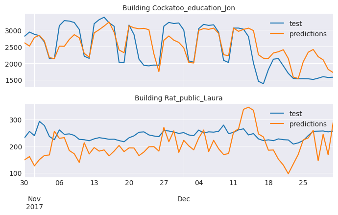

```python
# Plot predictions vs real value for 2 random buildings
# ==============================================================================
rng = np.random.default_rng(14793)
n_buildings = 2
selected_buildings = rng.choice(data['building_id'].unique(), size=n_buildings, replace=False)

fig, axs = plt.subplots(n_buildings, 1, figsize=(7, 4.5), sharex=True)
axs = axs.flatten()

for i, building in enumerate(selected_buildings):
    data.query("building_id == @building").loc[predictions.index, 'meter_reading'].plot(ax=axs[i], label='test')
    predictions[building].plot(ax=axs[i], label='predictions')
    axs[i].set_title(f"Building {building}", fontsize=10)
    axs[i].set_xlabel("")
    axs[i].legend()

fig.tight_layout()
plt.show();
```

## Session information

```python
import session_info
session_info.show(html=False)
```

```
-----
lightgbm            4.4.0
matplotlib          3.8.4
numpy               1.26.4
optuna              3.6.1
pandas              2.2.2
session_info        1.0.0
skforecast          0.13.0
sklearn             1.4.2
-----
IPython             8.26.0
jupyter_client      8.6.2
jupyter_core        5.7.2
notebook            6.0.0
-----
Python 3.12.4 | packaged by Anaconda, Inc. | (main, Jun 18 2024, 15:12:24) [GCC 11.2.0]
Linux-5.15.0-1064-aws-x86_64-with-glibc2.31
-----
Session information updated at 2024-07-24 14:16
```

## Citation

**How to cite this document**

If you use this document or any part of it, please acknowledge the source, thank you!

Global Forecasting Models: Comparative Analysis of Single and Multi-Series Forecasting Modeling by Joaquín Amat Rodrigo and Javier Escobar Ortiz, available under a CC BY-NC-SA 4.0 at https://www.cienciadedatos.net/documentos/py53-global-forecasting-models.html

**How to cite skforecast**

If you use skforecast for a scientific publication, we would appreciate it if you cite the published software.

Zenodo:

Amat Rodrigo, Joaquin, & Escobar Ortiz, Javier. (2023). skforecast (v0.11.0). Zenodo. https://doi.org/10.5281/zenodo.8382788

APA:

Amat Rodrigo, J., & Escobar Ortiz, J. (2023). skforecast (Version 0.11.0) [Computer software]. https://doi.org/10.5281/zenodo.8382788

BibTeX:

@software{skforecast, author = {Amat Rodrigo, Joaquin and Escobar Ortiz, Javier}, title = {skforecast}, version = {0.11.0}, month = {11}, year = {2023}, license = {BSD-3-Clause}, url = {https://skforecast.org/}, doi = {10.5281/zenodo.8382788} }

This work by Joaquín Amat Rodrigo and Javier Escobar Ortiz is licensed under a [Creative Commons Attribution-NonCommercial-ShareAlike 4.0 International License](https://creativecommons.org/licenses/by-nc-sa/4.0/).